# MUC5AC Fine-mapping analysis

Noemi Nicole Piga

30 June, 2023

```r
#library reticulate to be able to add chuncks in another language
library(reticulate)
# To run this .rmd file in a terminal being in the project folder:
#export PATH=${PATH}:/cm/shared/apps/R/deps/rstudio/bin/pandoc
#file="./report/Report_muc5a_finemapping.Rmd"
#module unload R/4.2.1
#module load R/4.1.0
#Rscript -e 'rmarkdown::render("'$file'")'
```

# Rationale

Using PolyFun+SuSie [1] or SuSiE [2] to fine-map the MUC5AC region in Shrine et al. moderate-severe asthma [3] and Global Biobank Meta-analysis Initiative (GBMI) asthma summary statistics [4] for European ancestry individuals; compare them to each other and the chronic sputum study [5].  
SuSiE is a software for bayesian fine-mapping that allows up to 10 variants to be causal in a credibel set. Polyfun is a software that allows the use of prior probabilities as per-SNP heritability calculated based on multiple functional annotations/measures [1]; The posterior probability is calculated using the SNP’s marginal effect size (from the GWAS analysis) together with the prior (https://github.com/omerwe/polyfun/issues/131).  
For moderate-to-severe, I was able to use SuSiE with individual level data. For GBMI, I had to use the LD matrix as calculated by Polyfun’s author in White British European from UK Biobank [1].  
From the fine-mapping output, I retrieved the credible set as identified by SuSiE (‘CREDIBLE SET’ column equal to 1). If SuSiE did not output any credible set, I identified the credible set including variants with decreasing posterior probability until their cumulative sum reached 0.95.

# Analysis

Github repository page: https://github.com/legenepi/muc5a_finemapping  
Code: /home/n/nnp5/PhD/PhD_project/muc5a_finemapping/src/polyfun_susie.sh

```r
#!/bin/bash

#set up local variable, environment to use:
path_dir="/home/n/nnp5/PhD/PhD_project/muc5a_finemapping"
module load python/gcc/3.9.10
conda activate polyfun
module load gcc/9.3
cd ${path_dir}/

#required install:
#install parquet-tools to read parquet file in bash: python3 -m pip install parquet-tools

##MODERATE-TO-SEVERE:
#Step1. Create a munged summary statistics file in a PolyFun-friendly parquet format.
#SNP    Chromosome  Position_b37    Coded Non_coded Coded_freq  INFO    beta    SE_GC P_GC
zcat /rfs/TobinGroup/kaf19/Public_data/ukb_mod_sev_asthma/Shrine_30552067_moderate-severe_asthma.txt.gz | \
    sed 's/Position_b37/BP/g' | \
    sed 's/SE_GC/SE/g' | \
    sed 's/P_GC/P/g' | \
    sed 's/#SNP/SNP/g' | awk -F "\t" '{print $1, $2, $3, $4, $5, $6, $7, $8, $9, $13}' > ${path_dir}/input/modsev_sumstat

sed -i 's/Coded/A1/g' ${path_dir}/input/modsev_sumstat
sed -i 's/Non_coded/A2/g' ${path_dir}/input/modsev_sumstat
sed -i 's/Coded_freq/A1_freq/g' ${path_dir}/input/modsev_sumstat

#create MAF in R:
module unload R/4.2.1
module load R/4.1.0
dos2unix ${path_dir}/src/create_maf.R
chmod o+x ${path_dir}/src/create_maf.R
Rscript ${path_dir}/src/create_maf.R

#Run Polyfun:
##Create parquet file:
python /home/n/nnp5/software/polyfun/munge_polyfun_sumstats.py \
  --sumstats ${path_dir}/input/modsev_sumstat_maf \
  --n 30810 \
  --out ${path_dir}/input/modsev_sumstats_munged.parquet \
  --min-info 0.85 \
  --min-maf 0.01

#Approach 1 (UK Biobank pre-computed prior causal probabilities); no information for HLA region !
##A.Extract pre-computed prior causal probabilities in UK Biobank - White British:
python /home/n/nnp5/software/polyfun/extract_snpvar.py \
    --sumstats ${path_dir}/input/modsev_sumstats_munged.parquet \
    --allow-missing \
    --out ${path_dir}/input/modsev_SNPs_PriCauPro

#Sentinel variant: rs11603634
#BP37: 1136478
#+/- 500000
start=$((1136478-500000))
end=$((1136478+500000))

#Download pre-computed LD matrix from British ancestry UK Biobank individuals:
wget https://broad-alkesgroup-ukbb-ld.s3.amazonaws.com/UKBB_LD/chr11_1_3000001.npz
wget https://broad-alkesgroup-ukbb-ld.s3.amazonaws.com/UKBB_LD/chr11_1_3000001.gz

#Run the actual FIFO:
python /home/n/nnp5/software/polyfun/finemapper.py \
    --ld ${path_dir}/input/chr11_1_3000001 \
    --sumstats ${path_dir}/input/modsev_SNPs_PriCauPro \
    --n 30810 \
    --chr 11 \
    --start 636478 \
    --end 1636478 \
    --method susie \
    --max-num-causal 10 \
    --allow-missing \
    --out ${path_dir}/output/polyfun_susie_modsev

#Extract credset 95% in R
dos2unix ${path_dir}/src/credset.R
chmod o+x ${path_dir}/src/credset.R
Rscript ${path_dir}/src/credset.R \
    ${path_dir}/output/polyfun_susie_modsev \
    ${path_dir}/output/polyfun_susie_modsev_credset \
    ${path_dir}/output/polyfun_susie_modsev_credset_credsetbysusie

#NO FUNCTIONAL PRIORS in modsev:
#--non-funct parameter for non-functionally informed fine-mapping
python /home/n/nnp5/software/polyfun/finemapper.py \
    --ld ${path_dir}/input/chr11_1_3000001 \
    --sumstats ${path_dir}/input/modsev_sumstats_munged.parquet \
    --n 30810 \
    --chr 11 \
    --start 636478 \
    --end 1636478 \
    --method susie \
    --non-funct \
    --max-num-causal 10 \
    --allow-missing \
    --out ${path_dir}/output/polyfun_susie_modsev_noprior
Rscript ${path_dir}/src/credset.R \
    ${path_dir}/output/polyfun_susie_modsev_noprior \
    ${path_dir}/output/polyfun_susie_modsev_noprior_credset \
    ${path_dir}/output/polyfun_susie_modsev_noprior_credsetbysusie

#modesev credible set by susie is empty. 'credible set' column is 0 for all variants. Use the cumsum pip <= 0.95 strategy.

#####################################
#GBMI ALL-COMER ASTHMA IN EUROPEAN:
#/rfs/TobinGroup/kaf19/Public_data/gbmi_asthma/Asthma_Bothsex_eur_inv_var_meta_GBMI_052021_nbbkgt1.txt.gz

##ALT is the coded allele:
#CHR    POS REF ALT rsid    all_meta_AF inv_var_meta_beta   inv_var_meta_sebeta inv_var_meta_p  inv_var_het_p   direction   N_case  N_ctrl  n_dataset   n_bbk   is_strand_flip  is_diff_AF_gnomAD
zcat /rfs/TobinGroup/kaf19/Public_data/gbmi_asthma/Asthma_Bothsex_eur_inv_var_meta_GBMI_052021_nbbkgt1.txt.gz | \
    awk '{print $1, $2, $3, $4, $5, $6, $7, $8, $9, $12+$13}' | sed 's/#CHR/Chromosome/g' | \
    sed 's/POS/BP/g' | sed 's/REF/A2/g' | sed 's/ALT/A1/g' | sed 's/rsid/SNP/g' | \
    sed 's/all_meta_AF/A1_freq/g' | sed 's/inv_var_meta_beta/beta/g' | \
    sed 's/inv_var_meta_sebeta/SE/g' | sed 's/inv_var_meta_p/P/g' > ${path_dir}/input/gbmi_eur_sumstat

##GRCh38: use liftover to convert in GRCh37

#Extract variants of interest and create MAF in R:
module unload R/4.2.1
module load R/4.1.0
dos2unix ${path_dir}/src/create_maf_gbmi.R
chmod o+x ${path_dir}/src/create_maf_gbmi.R
Rscript ${path_dir}/src/create_maf_gbmi.R

#convert sentinel SNPs interactively with liftOver (GRCh37 to GRCh38): https://genome.ucsc.edu/cgi-bin/hgLiftOver
#and then download the file for broad pheno sentinel vars.
awk '{print "chr"$1, $2, $2}' ${path_dir}/input/b38_chr11_gbmi_eur_sumstat_maf | \
    tail -n +2 > ${path_dir}/input/b38_chr11_gbmi.bed

#Successfully converted 1341801 records
#Conversion failed on 805 records.
##Explain failure messages:
#Deleted in new:
#    Sequence intersects no chains
#Partially deleted in new:
#    Sequence insufficiently intersects one chain
#Split in new:
#    Sequence insufficiently intersects multiple chains
#Duplicated in new:
#    Sequence sufficiently intersects multiple chains
#Boundary problem:
#    Missing start or end base in an exon

#Update the BP with GRCh37:
awk -F "\t|:|-" '{print $6}' ${path_dir}/input/b37_chr11_gbmi.bed | \
    grep -F -w -f - ${path_dir}/input/b38_chr11_gbmi_eur_sumstat_maf \
    > ${path_dir}/input/b38_with_b37_chr11_gbmi_sumstat

#in R:
dos2unix ${path_dir}/src/gbmi_b37.R
chmod o+x ${path_dir}/src/gbmi_b37.R
Rscript ${path_dir}/src/gbmi_b37.R

#Run Polyfun:
##Create parquet file:
python /home/n/nnp5/software/polyfun/munge_polyfun_sumstats.py \
  --sumstats ${path_dir}/input/b37_chr11_gbmi_eur_sumstat_maf \
  --out ${path_dir}/input/gbmi_eur_sumstats_munged.parquet \
  --min-info 0.85 \
  --min-maf 0.01
```

```r
#Approach 1 (UK Biobank pre-computed prior causal probabilities); no information for HLA region !
##A.Extract pre-computed prior causal probabilities in UK Biobank - White British:
python /home/n/nnp5/software/polyfun/extract_snpvar.py \
    --sumstats ${path_dir}/input/gbmi_eur_sumstats_munged.parquet \
    --allow-missing \
    --out ${path_dir}/input/gbmi_eur_SNPs_PriCauPro

#Download pre-computed LD matrix from British ancestry UK Biobank individuals:
#rs11245964 is te sentinel variant from GBMI eur all-comer asthma.
#1119370 GRCh38
#1113278 GRCh37
start=$((1113278 - 500000))
end=$((1113278 + 500000))

#The same that I downloaded for moderate-to-severe (do not run it):
#wget https://broad-alkesgroup-ukbb-ld.s3.amazonaws.com/UKBB_LD/chr11_1_3000001.npz
#wget https://broad-alkesgroup-ukbb-ld.s3.amazonaws.com/UKBB_LD/chr11_1_3000001.gz

#Run the actual FIFO:
#median N-sample size: 1376100
#max N-sample size: 1376100
#min N-sample size: 26133
#USING MEDIAN VALUE FOR n-SAMPLE SIZE:
python /home/n/nnp5/software/polyfun/finemapper.py \
    --ld ${path_dir}/input/chr11_1_3000001 \
    --sumstats ${path_dir}/input/gbmi_eur_SNPs_PriCauPro \
    --n 1376100 \
    --chr 11 \
    --start $start \
    --end $end \
    --method susie \
    --max-num-causal 10 \
    --allow-missing \
    --out ${path_dir}/output/polyfun_susie_gbmi_eur_Nmedian

python /home/n/nnp5/software/polyfun/finemapper.py \
    --ld ${path_dir}/input/chr11_1_3000001 \
    --sumstats ${path_dir}/input/gbmi_eur_SNPs_PriCauPro \
    --n 26133 \
    --chr 11 \
    --start $start \
    --end $end \
    --method susie \
    --max-num-causal 10 \
    --allow-missing \
    --out ${path_dir}/output/polyfun_susie_gbmi_eur_Nmin

#NO FUNCTIONAL PRIORS in GBMI:
start=$((1113278 - 500000))
end=$((1113278 + 500000))
python /home/n/nnp5/software/polyfun/finemapper.py \
    --ld ${path_dir}/input/chr11_1_3000001 \
    --sumstats ${path_dir}/input/gbmi_eur_sumstats_munged.parquet \
    --n 1376100 \
    --chr 11 \
    --start $start \
    --end $end \
    --method susie \
    --non-funct \
    --max-num-causal 10 \
    --allow-missing \
    --out ${path_dir}/output/polyfun_susie_gbmi_eur_Nmedian_noprior

conda deactivate polyfun

#Extract credset 95% in R:
Rscript ${path_dir}/src/credset.R \
    ${path_dir}/output/polyfun_susie_gbmi_eur_Nmedian \
    ${path_dir}/output/polyfun_susie_gbmi_eur_credset_Nmedian \
    ${path_dir}/output/polyfun_susie_gbmi_eur_Nmedian_credsetbysusie

Rscript ${path_dir}/src/credset.R \
    ${path_dir}/output/polyfun_susie_gbmi_eur_Nmin \
    ${path_dir}/output/polyfun_susie_gbmi_eur_credset_Nmin \
    ${path_dir}/output/polyfun_susie_gbmi_eur_Nmin_credsetbysusie

Rscript ${path_dir}/src/credset.R \
    ${path_dir}/output/polyfun_susie_gbmi_eur_Nmedian_noprior \
    ${path_dir}/output/polyfun_susie_gbmi_eur_Nmedian_noprior_credset \
    ${path_dir}/output/polyfun_susie_gbmi_eur_Nmedian_noprior_credsetbysusie

#In R, make Venn diagram comparing the three fine-mapping credible sets:
#PolyFun + SuSiE:
Rscript ${path_dir}/src/compare_credset.R\
    ${path_dir}/input/chronic_sputum_suppl.xlsx \
    ${path_dir}/output/polyfun_susie_modsev_credset \
    ${path_dir}/output/polyfun_susie_gbmi_eur_Nmedian_credsetbysusie \
    "_gbmibysusie" \
    "chronic sputum" \
    "moderate-to-severe" \
    "GBMI-all comer asthma credset by susie"

#SuSiE
Rscript ${path_dir}/src/compare_credset.R\
    ${path_dir}/input/chronic_sputum_suppl.xlsx \
    ${path_dir}/output/polyfun_susie_modsev_noprior_credset \
    ${path_dir}/output/polyfun_susie_gbmi_eur_Nmedian_noprior_credsetbysusie \
    "_modsevnoprior_gbminopriorbysusie" \
    "chronic sputum" \
    "moderate-to-severe no prior" \
    "GBMI-all comer asthma no prior credset by susie"

#Using the credible set as found by susie:
#In order for variables to be in a rho credible set, their PIP have to sum to greater than or equal to rho,
#and their "purity", defined by minimum absolute pairwise correlation, should be greater than or equal to r.
# Currently, rho is set to 0.95 and r is set to 0.5. You can lower either these numbers, or both,
# to be more lenient with credible sets, depending on your analysis context (current default is
# what we believe reasonable for genetic fine-mapping applications)

#QC:
#MODSEV: 441 variants not in fine-mapping
zcat input/modsev_SNPs_PriCauPro.miss.gz | awk -F "\t" '$2 == 11 && $3 >= 636478 && $3 <= 1636478 {print}' | wc -l
#2 variants not in fine-mapping for modsev and found in the credset of chronic sputum:
zcat input/modsev_SNPs_PriCauPro.miss.gz | awk -F "\t" '$2 == 11 && $3 >= 636478 && $3 <= 1636478 {print $3}' | \
    grep -F -f - input/chronic_sputum_credset_muc2
#GBMI: 389 variants not in fine-mapping
zcat input/gbmi_eur_SNPs_PriCauPro.miss.gz | awk -F "\t" '$2 >= 613278 && $2 <= 1613278 {print}' | wc -l
#2 variants not in fine-mapping for gbmi and found in the credset of chronic sputum (same x modsev):
zcat input/gbmi_eur_SNPs_PriCauPro.miss.gz | awk -F "\t" '$2 >= 613278 && $2 <= 1613278 {print $2}' | \
    grep -F -f - input/chronic_sputum_credset_muc2

#Look at sentinel variants in other study:
#moderate-to-severe sentinel variant: rs11603634
grep -w "rs11603634" /data/gen1/Phlegm/Results_files/GWAS/combined_results_INFO_MAC20
grep "1136478" ${path_dir}/input/chronic_sputum_credset_muc2
zgrep -w "rs11603634" /rfs/TobinGroup/kaf19/Public_data/gbmi_asthma/Asthma_Bothsex_eur_inv_var_meta_GBMI_052021_nbbkgt1.txt.gz
grep -w "rs11603634" ${path_dir}/output/polyfun_susie_gbmi_eur_Nmedian
#chronic sputum sentinel variant: rs779167905, BP:1116931 (rs35606069 in moderate-to-severe)
zgrep "1116931" /rfs/TobinGroup/kaf19/Public_data/ukb_mod_sev_asthma/Shrine_30552067_moderate-severe_asthma.txt.gz
grep "1116931" ${path_dir}/output/polyfun_susie_modsev
zgrep -w "1116931" ${path_dir}/modsev_SNPs_PriCauPro.miss.gz
zgrep -w "rs779167905" /rfs/TobinGroup/kaf19/Public_data/gbmi_asthma/Asthma_Bothsex_eur_inv_var_meta_GBMI_052021_nbbkgt1.txt.gz
grep -w "1116931" ${path_dir}/output/polyfun_susie_gbmi_eur_Nmedian
zgrep -w "1116931" /rfs/TobinGroup/kaf19/Public_data/gbmi_asthma/Asthma_Bothsex_eur_inv_var_meta_GBMI_052021_nbbkgt1.txt.gz
#GBMI sentinel variant: rs11245964
zgrep "rs11245964" /rfs/TobinGroup/kaf19/Public_data/ukb_mod_sev_asthma/Shrine_30552067_moderate-severe_asthma.txt.gz
grep "rs11245964" ${path_dir}/output/polyfun_susie_modsev
grep -w "rs11245964" /data/gen1/Phlegm/Results_files/GWAS/combined_results_INFO_MAC20
```

```r
#cp final output into output_final:
cp output/polyfun_susie_modsev \
    output/polyfun_susie_gbmi_eur_Nmedian \
    output/polyfun_susie_modsev_credset \
    output/polyfun_susie_gbmi_eur_Nmedian_credsetbysusie \
    muc5ac_finemap_output_30062023/

cp output/polyfun_susie_modsev_noprior \
    output/polyfun_susie_gbmi_eur_Nmedian_noprior \
    output/polyfun_susie_modsev_noprior_credset \
    output/polyfun_susie_gbmi_eur_Nmedian_noprior_credsetbysusie \
    muc5ac_finemap_output_30062023/

cp output/credset_3_gwas_gbmibysusie \
    output/credset_3_gwas_modsevnoprior_gbminopriorbysusie \
    muc5ac_finemap_output_30062023/
```

Code: /home/n/nnp5/PhD/PhD_project/muc5a_finemapping/src/create_maf.R

```r
#!/usr/bin/env Rscript

suppressMessages(library(tidyverse))
suppressMessages(library(data.table))
df <- fread("/home/n/nnp5/PhD/PhD_project/muc5a_finemapping/input/modsev_sumstat")
df <- df %>% mutate(MAF=ifelse(df$A1_freq <= 0.5, df$A1_freq, 1-df$A1_freq))
fwrite(df,"/home/n/nnp5/PhD/PhD_project/muc5a_finemapping/input/modsev_sumstat_maf",sep=" ",quote=F,row.names=F)
```

Code: /home/n/nnp5/PhD/PhD_project/muc5a_finemapping/src/credset.R

```r
#!/usr/bin/env Rscript

library(tidyverse)
library(data.table)
args = commandArgs(trailingOnly=TRUE)
df <- fread(args[1])
head(df)
dim(df)
df$cumsum_pip <- cumsum(df$PIP)
credset <- df %>% filter(cumsum_pip <= 0.95)
dim(credset)
fwrite(credset,args[2],row.names=F,quote=F)

credset_bysusie <- df %>% filter(CREDIBLE_SET == 1)
fwrite(credset_bysusie,args[3],row.names=F,quote=F)
```

Code: /home/n/nnp5/PhD/PhD_project/muc5a_finemapping/src/create_maf_gbmi.R

```r
#!/usr/bin/env Rscript

suppressMessages(library(tidyverse))
suppressMessages(library(data.table))
df <- fread("/home/n/nnp5/PhD/PhD_project/muc5a_finemapping/input/gbmi_eur_sumstat")
df <- df %>% mutate(MAF=ifelse(df$A1_freq <= 0.5, df$A1_freq, 1-df$A1_freq))
#Rename N-sample size col:
colnames(df)[10] <- "N"
df <- df %>% filter(Chromosome == 11)
write.table(df,"/home/n/nnp5/PhD/PhD_project/muc5a_finemapping/input/b38_chr11_gbmi_eur_sumstat_maf", na="NA", sep=" ",quote=F,row.names=F)
```

Code: /home/n/nnp5/PhD/PhD_project/muc5a_finemapping/src/gbmi_b37.R

```r
#!/usr/bin/env Rscript

suppressMessages(library(tidyverse))
suppressMessages(library(data.table))
gbmi_sumstat <- fread("/home/n/nnp5/PhD/PhD_project/muc5a_finemapping/input/b38_with_b37_chr11_gbmi_sumstat")
colnames(gbmi_sumstat) <- c("Chromosome","BP","A2","A1","SNP","A1_freq","beta","SE","P","N","MAF")
gbmi_sumstat$BP <- as.numeric(gbmi_sumstat$BP)
gbmi_sumstat <- gbmi_sumstat %>% arrange(BP)
gbmi_sumstat$index <- seq(0,dim(gbmi_sumstat)[1]-1)
b37 <- fread("/home/n/nnp5/PhD/PhD_project/muc5a_finemapping/input/b37_chr11_gbmi.bed")
b37 <- b37 %>% separate(V4, c("CHR","discard","BP"),sep=c(":|-"))
b37$discard <- NULL
b37$BP <- as.numeric(b37$BP)
b37 <- b37 %>% arrange(BP)
b37$index <- seq(0,dim(b37)[1]-1)
gbmi_sumstat_b37 <- left_join(b37,gbmi_sumstat,by=c("BP","index"))
gbmi_sumstat_b37 <- gbmi_sumstat_b37 %>% rename(BP37 = V2)
gbmi_sumstat_b37 <- gbmi_sumstat_b37 %>% select(Chromosome, BP37, A2, A1, SNP, A1_freq, beta, SE, P, N, MAF)
gbmi_sumstat_b37 <- gbmi_sumstat_b37 %>% rename(BP = BP37, CHR = Chromosome)
gbmi_sumstat_b37 <- gbmi_sumstat_b37 %>% distinct(BP, .keep_all=T)
write.table(gbmi_sumstat_b37,"/home/n/nnp5/PhD/PhD_project/muc5a_finemapping/input/b37_chr11_gbmi_eur_sumstat_maf", na="NA", sep=" ",quote=F,row.names=F)
```

Code: /home/n/nnp5/PhD/PhD_project/muc5a_finemapping/src/compare_credset.R

```r
#!/usr/bin/env Rscript

library(tidyverse)
library(data.table)
library(readxl)
library(VennDiagram)
library(gplots)

args = commandArgs(trailingOnly=TRUE)

#input credset:
chsp <- read_xlsx(args[1], sheet="S10-Credible sets", skip = 1, col_names=T)
modsev <- fread(args[2])
gbmi <- fread(args[3])
suffix_output <- args[4]


#Data pre-processing:
colnames(chsp)[2] <- "to_separate"
chsp <- chsp %>% separate(to_separate, c("CHR", "BP"), sep=":")
colnames(chsp)[5] <- "to_separate2"
chsp <- chsp %>% separate(to_separate2, c("A1", "A2"), sep="/")
chsp <- chsp %>% filter(Locus == "MUC2")
chsp <- chsp %>% rename(SNP = RSID)
chsp <- chsp %>% rename(PIP = 'Posterior probability')
#Select cols of interest:
chsp <- chsp %>% select("CHR","BP","SNP","A1","A2","P","PIP")
colnames(chsp) <- paste("chsp", colnames(chsp), sep = "_")
modsev <- modsev %>% select("CHR","BP","SNP","A1","A2","P","PIP")
colnames(modsev) <- paste("modsev", colnames(modsev), sep = "_")
gbmi <- gbmi %>% select("CHR","BP","SNP","A1","A2","P","PIP")
colnames(gbmi) <- paste("gbmi", colnames(gbmi), sep = "_")
#join the dataset to have a unique file with the results:
chsp <- chsp %>% rename(BP = chsp_BP)
chsp$BP <- as.numeric(chsp$BP)
modsev <- modsev %>% rename(BP = modsev_BP)
modsev$BP <- as.numeric(modsev$BP)
gbmi <- gbmi %>% rename(BP = gbmi_BP)
gbmi$BP <- as.numeric(gbmi$BP)

chsp <- chsp %>% rename(SNP = chsp_SNP)
modsev <- modsev %>% rename(SNP = modsev_SNP)
gbmi <- gbmi %>% rename(SNP = gbmi_SNP)

chsp <- chsp %>% rename(CHR = chsp_CHR)
chsp$CHR <- as.numeric(chsp$CHR)
modsev <- modsev %>% rename(CHR = modsev_CHR)
modsev$CHR <- as.numeric(modsev$CHR)
gbmi <- gbmi %>% rename(CHR = gbmi_CHR)
gbmi$CHR <- as.numeric(gbmi$CHR)

#join dfs:
chsp_modsev <- full_join(chsp,modsev,by=c("BP","CHR"))
chsp_modsev_gbmi <- full_join(chsp_modsev,gbmi,by=c("BP","CHR"))
chsp_modsev_gbmi <- chsp_modsev_gbmi %>% arrange(BP)

write.table(chsp_modsev_gbmi,paste0("output/credset_3_gwas",suffix_output), na="NA", sep=" ",quote=F,row.names=F)


#plot
flog.threshold(ERROR) #to avoid the log file to be produced
venn.diagram(
   x = list(
     chsp %>% select(BP) %>% distinct() %>% unlist(),
     modsev %>%  select(BP) %>% distinct() %>% unlist(),
     gbmi %>%  select(BP) %>% distinct() %>% unlist()
    ),
   category.names = c(args[5], args[6], args[7]),
   filename = paste0("output/Venn_asthma_credset",suffix_output,".png"),
   output = TRUE ,
           imagetype="png" ,
           height = 1100 ,
           width = 1500 ,
           resolution = 400,
           compression = "lzw",
           lwd = 1,
           col=c("#440154ff", '#21908dff', '#fde725ff'),
           fill = c(alpha("#440154ff",0.3), alpha('#21908dff',0.3), alpha('#fde725ff',0.3)),
           cex = 0.5,
           fontfamily = "sans",
           cat.cex = 0.3,
           cat.default.pos = "outer")


#use venn() in package gplots to obtain the list of participants for each intersection:
listInput <- list(chsp %>% select(BP) %>% distinct() %>% unlist(),
     modsev %>%  select(BP) %>% distinct() %>% unlist(),
     gbmi %>%  select(BP) %>% distinct() %>% unlist())
ItemsList <- venn(listInput, show.plot = FALSE, category.names = c("chronic sputum", "moderate-to-severe", "GBMI-all comer asthma"))

#write into an output file the intersection:
file.create(paste0("output/Intersection_asthma_credset_BP_list",suffix_output))
for (i in seq(1,length(attributes(ItemsList)$intersections))) {
write.table(attributes(ItemsList)$intersections[i],paste0("output/Intersection_asthma_credset_BP_list",suffix_output),append=T,row.names = FALSE, quote=FALSE)}
```

Code: /home/n/nnp5/PhD/PhD_project/muc5a_finemapping/src/test_polyfun_susie.sh

```r
#!/bin/bash

#Rationale: test different info thresholds and number of maximum causal variants for polyfun+susie analysis

#set up local variable, environment to use:
path_dir="/home/n/nnp5/PhD/PhD_project/muc5a_finemapping"
module load gcc/9.3
module load python/gcc/3.9.10
cd ${path_dir}/
module unload R/4.2.1
module load R/4.1.0
conda activate polyfun

##MODERATE-TO-SEVERE:
#${path_dir}/input/modsev_sumstat_maf already created in polyfun_susie.sh
#Sentinel variant: rs11603634
#BP37: 1136478
#+/- 500000: 636478, 1636478
start=$((1136478-500000))
end=$((1136478+500000))

## INFO 085, --max-num-causal 1:
python /home/n/nnp5/software/polyfun/finemapper.py \
    --sumstats ${path_dir}/input/modsev_SNPs_PriCauPro \
    --n 30810 \
    --chr 11 \
    --start ${start} \
    --end  ${end} \
    --method susie \
    --max-num-causal 1 \
    --allow-missing \
    --out ${path_dir}/output/N1_polyfun_susie_modsev
#Extract credset 95% in R
Rscript ${path_dir}/src/credset.R ${path_dir}/output/N1_polyfun_susie_modsev ${path_dir}/output/N1_polyfun_susie_modsev_credset

##INFO 09: I need to create parquet file with --min-info 0.9 and extract snpvar again:
#Run Polyfun:
##Create parquet file:
python /home/n/nnp5/software/polyfun/munge_polyfun_sumstats.py \
  --sumstats ${path_dir}/input/modsev_sumstat_maf \
  --n 30810 \
  --out ${path_dir}/input/info09_modsev_sumstats_munged.parquet \
  --min-info 0.9 \
  --min-maf 0.01

#Approach 1 (UK Biobank pre-computed prior causal probabilities); no information for HLA region !
##A.Extract pre-computed prior causal probabilities in UK Biobank - White British:
python /home/n/nnp5/software/polyfun/extract_snpvar.py \
    --sumstats ${path_dir}/input/info09_modsev_sumstats_munged.parquet \
    --allow-missing \
    --out ${path_dir}/input/info09_modsev_SNPs_PriCauPro

#Run FIFO:
## INFO 09, --max-num-causal 10:
python /home/n/nnp5/software/polyfun/finemapper.py \
    --ld ${path_dir}/input/chr11_1_3000001 \
    --sumstats ${path_dir}/input/info09_modsev_SNPs_PriCauPro \
    --n 30810 \
    --chr 11 \
    --start ${start} \
    --end  ${end} \
    --method susie \
    --max-num-causal 10 \
    --allow-missing \
    --out ${path_dir}/output/info09_polyfun_susie_modsev
#Extract credset 95% in R
Rscript ${path_dir}/src/credset.R ${path_dir}/output/info09_polyfun_susie_modsev ${path_dir}/output/info09_polyfun_susie_modsev_credset

## INFO 09, --max-num-causal 1:
python /home/n/nnp5/software/polyfun/finemapper.py \
    --sumstats ${path_dir}/input/info09_modsev_SNPs_PriCauPro \
    --n 30810 \
    --chr 11 \
    --start 636478 \
    --end 1636478 \
    --method susie \
    --max-num-causal 1 \
    --allow-missing \
    --out ${path_dir}/output/N1_info09_polyfun_susie_modsev
#Extract credset 95% in R
Rscript ${path_dir}/src/credset.R ${path_dir}/output/N1_info09_polyfun_susie_modsev ${path_dir}/output/N1_info09_polyfun_susie_modsev_credset


#COMPARE DIFFERENT INFO AND MAXIMUM NUMBER OF CAUSAL VARIANTS FOR MODERATE-TO-SEVERE:
dos2unix ${path_dir}/src/compare_different_params.R
chmod o+x ${path_dir}/src/compare_different_params.R
Rscript ${path_dir}/src/compare_different_params.R \
    ${path_dir}/output/polyfun_susie_modsev_credset "info_085_N10" \
    ${path_dir}/output/N1_polyfun_susie_modsev_credset "info_085_N1" \
    ${path_dir}/output/info09_polyfun_susie_modsev_credset "info_090_N10" \
    ${path_dir}/output/N1_info09_polyfun_susie_modsev_credset "info_090_N1" \
    ${path_dir}/output/Venn_asthma_credset_modsev_params.png \
    ${path_dir}/output/Intersection_asthma_credset_modsev_params_BP_list

#####################################
#GBMI ALL-COMER ASTHMA IN EUROPEAN:
#rs11245964 is te sentinel variant from GBMI eur all-comer asthma.
#1119370 GRCh38
#1113278 GRCh37
start=$((1113278 - 500000))
end=$((1113278 + 500000))

#Run the actual FIFO:
#median N-sample size: 1376100
#max N-sample size: 1376100
#min N-sample size: 26133
#INFO 085, N-MEDIAN, --max-num-causal 1:
python /home/n/nnp5/software/polyfun/finemapper.py \
    --sumstats ${path_dir}/input/gbmi_eur_SNPs_PriCauPro \
    --n 1376100 \
    --chr 11 \
    --start $start \
    --end $end \
    --method susie \
    --max-num-causal 1 \
    --allow-missing \
    --out ${path_dir}/output/polyfun_susie_gbmi_eur_Nmedian_N1
#Extract credset 95% in R:
Rscript ${path_dir}/src/credset.R ${path_dir}/output/polyfun_susie_gbmi_eur_Nmedian_N1 ${path_dir}/output/polyfun_susie_gbmi_eur_credset_Nmedian_N1

#INFO 085, N-MIN, --max-num-causal 1:
python /home/n/nnp5/software/polyfun/finemapper.py \
    --sumstats ${path_dir}/input/gbmi_eur_SNPs_PriCauPro \
    --n 26133 \
    --chr 11 \
    --start $start \
    --end $end \
    --method susie \
    --max-num-causal 1 \
    --allow-missing \
    --out ${path_dir}/output/polyfun_susie_gbmi_eur_Nmin_N1
#Extract credset 95% in R:
Rscript ${path_dir}/src/credset.R ${path_dir}/output/polyfun_susie_gbmi_eur_Nmin_N1 ${path_dir}/output/polyfun_susie_gbmi_eur_credset_Nmin_N1

##INFO 09: I need to create parquet file with --min-info 0.9 and extract snpvar again:#Run Polyfun:
##Create parquet file:
python /home/n/nnp5/software/polyfun/munge_polyfun_sumstats.py \
  --sumstats ${path_dir}/input/b37_chr11_gbmi_eur_sumstat_maf \
  --out ${path_dir}/input/info09_gbmi_eur_sumstats_munged.parquet \
  --min-info 0.9\
  --min-maf 0.01

#Approach 1 (UK Biobank pre-computed prior causal probabilities); no information for HLA region !
##A.Extract pre-computed prior causal probabilities in UK Biobank - White British:
python /home/n/nnp5/software/polyfun/extract_snpvar.py \
    --sumstats ${path_dir}/input/info09_gbmi_eur_sumstats_munged.parquet \
    --allow-missing \
    --out ${path_dir}/input/info09_gbmi_eur_SNPs_PriCauPro

#INFO 09, N-MEDIAN, --max-num-causal 10:
python /home/n/nnp5/software/polyfun/finemapper.py \
    --ld ${path_dir}/input/chr11_1_3000001 \
    --sumstats ${path_dir}/input/info09_gbmi_eur_SNPs_PriCauPro \
    --n 1376100 \
    --chr 11 \
    --start $start \
    --end $end \
    --method susie \
    --max-num-causal 10 \
    --allow-missing \
    --out ${path_dir}/output/info09_polyfun_susie_gbmi_eur_Nmedian
#Extract credset 95% in R:
Rscript ${path_dir}/src/credset.R ${path_dir}/output/info09_polyfun_susie_gbmi_eur_Nmedian ${path_dir}/output/info09_polyfun_susie_gbmi_eur_credset_Nmedian

#INFO 09, N-MEDIAN, --max-num-causal 1:
python /home/n/nnp5/software/polyfun/finemapper.py \
    --sumstats ${path_dir}/input/info09_gbmi_eur_SNPs_PriCauPro \
    --n 1376100 \
    --chr 11 \
    --start $start \
    --end $end \
    --method susie \
    --max-num-causal 1 \
    --allow-missing \
    --out ${path_dir}/output/info09_polyfun_susie_gbmi_eur_Nmedian_N1
#Extract credset 95% in R:
Rscript ${path_dir}/src/credset.R ${path_dir}/output/info09_polyfun_susie_gbmi_eur_Nmedian_N1 ${path_dir}/output/info09_polyfun_susie_gbmi_eur_credset_Nmedian_N1

#INFO 09, N-MIN, --max-num-causal 10:
python /home/n/nnp5/software/polyfun/finemapper.py \
    --ld ${path_dir}/input/chr11_1_3000001 \
    --sumstats ${path_dir}/input/info09_gbmi_eur_SNPs_PriCauPro \
    --n 26133 \
    --chr 11 \
    --start $start \
    --end $end \
    --method susie \
    --max-num-causal 10 \
    --allow-missing \
    --out ${path_dir}/output/info09_polyfun_susie_gbmi_eur_Nmin
Rscript ${path_dir}/src/credset.R ${path_dir}/output/info09_polyfun_susie_gbmi_eur_Nmin ${path_dir}/output/info09_polyfun_susie_gbmi_eur_credset_Nmin

#INFO 09, N-MIN, --max-num-causal 1:
python /home/n/nnp5/software/polyfun/finemapper.py \
    --sumstats ${path_dir}/input/info09_gbmi_eur_SNPs_PriCauPro \
    --n 26133 \
    --chr 11 \
    --start $start \
    --end $end \
    --method susie \
    --max-num-causal 1 \
    --allow-missing \
    --out ${path_dir}/output/info09_polyfun_susie_gbmi_eur_Nmin_N1
Rscript ${path_dir}/src/credset.R ${path_dir}/output/info09_polyfun_susie_gbmi_eur_Nmin_N1 ${path_dir}/output/info09_polyfun_susie_gbmi_eur_credset_Nmin_N1

#COMPARE DIFFERENT INFO AND MAXIMUM NUMBER OF CAUSAL VARIANTS FOR GBMI:
#N_median:
Rscript ${path_dir}/src/compare_different_params.R \
    ${path_dir}/output/polyfun_susie_gbmi_eur_credset_Nmedian "info_085_Nmedian_N10" \
    ${path_dir}/output/polyfun_susie_gbmi_eur_credset_Nmedian_N1 "info_085_Nmedian_N1" \
    ${path_dir}/output/info09_polyfun_susie_gbmi_eur_credset_Nmedian "info_090_Nmedian_N10" \
    ${path_dir}/output/info09_polyfun_susie_gbmi_eur_credset_Nmedian_N1 "info_090_Nmedian_N1" \
    ${path_dir}/output/Venn_asthma_credset_gbmi_Nmedian_params.png \
    ${path_dir}/output/Intersection_asthma_credset_gbmi_Nmedian_params_BP_list

#N-min:
Rscript ${path_dir}/src/compare_different_params.R \
    ${path_dir}/output/polyfun_susie_gbmi_eur_credset_Nmin "info_085_Nmin_N10" \
    ${path_dir}/output/polyfun_susie_gbmi_eur_credset_Nmin_N1 "info_085_Nmin_N1" \
    ${path_dir}/output/info09_polyfun_susie_gbmi_eur_credset_Nmin "info_090_Nmin_N10" \
    ${path_dir}/output/info09_polyfun_susie_gbmi_eur_credset_Nmin_N1 "info_090_Nmin_N1" \
    ${path_dir}/output/Venn_asthma_credset_gbmi_Nmin_params.png \
    ${path_dir}/output/Intersection_asthma_credset_gbmi_Nmin_params_BP_list

#comprare credsets:
dos2unix ${path_dir}/src/compare_credset.R
chmod o+x ${path_dir}/src/compare_credset.R
Rscript ${path_dir}/src/compare_credset.R\
    ${path_dir}/input/chronic_sputum_suppl.xlsx \
    ${path_dir}/output/polyfun_susie_modsev_credset \
    ${path_dir}/output/polyfun_susie_gbmi_eur_credset_Nmedian \
    "" \
    "chronic sputum" \
    "moderate-to-severe" \
    "GBMI-all comer asthma"

Rscript ${path_dir}/src/compare_credset.R\
    ${path_dir}/input/chronic_sputum_suppl.xlsx \
    ${path_dir}/output/polyfun_susie_modsev_noprior_credset \
    ${path_dir}/output/polyfun_susie_gbmi_eur_credset_Nmedian \
    "_modsevnoprior" \
    "chronic sputum" \
    "moderate-to-severe no prior" \
    "GBMI-all comer asthma"

Rscript ${path_dir}/src/compare_credset.R\
    ${path_dir}/input/chronic_sputum_suppl.xlsx \
    ${path_dir}/output/polyfun_susie_modsev_noprior_credset \
    ${path_dir}/output/polyfun_susie_gbmi_eur_Nmedian_credsetbysusie \
    "_modsevnoprior_gbmibysusie" \
    "chronic sputum" \
    "moderate-to-severe no prior" \
    "GBMI-all comer asthma credset by susie"

Rscript ${path_dir}/src/compare_credset.R\
    ${path_dir}/input/chronic_sputum_suppl.xlsx \
    ${path_dir}/output/polyfun_susie_modsev_noprior_credset \
    ${path_dir}/output/polyfun_susie_gbmi_eur_Nmedian_noprior_credset \
    "_modsevnoprior_gbminoprior" \
    "chronic sputum" \
    "moderate-to-severe no prior" \
    "GBMI-all comer asthma no prior"

#write in a separate file all the sumstat from suppl Table 10 just for Locus MUC2:
#library(tidyverse)
#library(readxl)
#chsp <- read_xlsx("input/chronic_sputum_suppl.xlsx",sheet="S10-Credible sets", skip = 1, col_names=T)
#chsp_muc2 <- chsp %>% filter(Locus == "MUC2")
#write.table(chsp_muc2,"input/chronic_sputum_credset_muc2_sumstat", na="NA", sep=" ",quote=F,row.names=F)
```

Code: /home/n/nnp5/PhD/PhD_project/muc5a_finemapping/src/compare_different_params.R

```r
#!/usr/bin/env Rscript

library(tidyverse)
library(data.table)
library(readxl)
library(VennDiagram)
library(gplots)

args = commandArgs(trailingOnly=TRUE)

df1 <- fread(args[1])
df1_type <- as.factor(args[2])

df2 <- fread(args[3])
df2_type <- as.factor(args[4])

df3 <- fread(args[5])
df3_type <- as.factor(args[6])

df4 <- fread(args[7])
df4_type <- as.factor(args[8])

venn.diagram(
   x = list(
     df1 %>% select(BP) %>% distinct() %>% unlist(),
     df2 %>%  select(BP) %>% distinct() %>% unlist(),
     df3 %>%  select(BP) %>% distinct() %>% unlist(),
     df4 %>%  select(BP) %>% distinct() %>% unlist()
    ),
   category.names = c(df1_type, df2_type, df3_type, df4_type),
   filename = args[9],
   output = TRUE ,
           imagetype="png" ,
           height = 1200 ,
           width = 1500 ,
           resolution = 400,
           compression = "lzw",
           lwd = 1,
           col=c("#440154ff", '#21908dff', '#fde725ff', 'Dark Olive Green 4'),
           fill = c(alpha("#440154ff",0.3), alpha('#21908dff',0.3), alpha('#fde725ff',0.3), alpha('Dark Olive Green 4',0.3)),
           cex = 0.5,
           fontfamily = "sans",
           cat.cex = 0.3,
           cat.default.pos = "outer")

#use venn() in package gplots to obtain the list of participants for each intersection:
listInput <- list(df1 %>% select(BP) %>% distinct() %>% unlist(),
     df2 %>%  select(BP) %>% distinct() %>% unlist(),
     df3 %>%  select(BP) %>% distinct() %>% unlist(),
     df4 %>%  select(BP) %>% distinct() %>% unlist())
ItemsList <- venn(listInput, show.plot = FALSE, category.names = c(df1_type, df2_type, df3_type, df4_type))
#write into an output file the intersection:
file.create(args[8])
for (i in seq(1,length(attributes(ItemsList)$intersections))) {
write.table(attributes(ItemsList)$intersections[i],args[10],append=T,row.names = FALSE, quote=FALSE)}
```

Code: /home/n/nnp5/PhD/PhD_project/muc5a_finemapping/src/Susie.sh

```r
#!/bin/bash

#PBS -N SuSie_muc5ac
#PBS -j oe
#PBS -o SuSie_muc5ac
#PBS -l walltime=32:0:0
#PBS -l vmem=50gb
#PBS -l nodes=1:ppn=1
#PBS -d .
#PBS -W umask=022

path_dir="/home/n/nnp5/PhD/PhD_project/muc5a_finemapping"
tmp_data="/scratch/gen1/nnp5/muc5a_finemapping/tmp_data"

cd ${path_dir}

module load gcc/9.3
module unload R/4.2.1
module load R/4.1.0
module load plink2

#input data:
#bgen:
#data/gen1/AIRPROM/imputation/chr11/chr11.hap.impute2.chunk01.bgen
#.sample
#awk '{print $1, $2, $3}' /data/gen1/AIRPROM/assoc/severe_asthma/airprom_pheno_array.sample \
#    > ${tmp_data}/modsev_all.sample
#awk 'NR == 1 || NR == 2 || $24 == 0 || $24 == 1 {print $1, $2, $3}' /data/gen1/AIRPROM/assoc/severe_asthma/airprom_pheno_array.sample \
#    > ${tmp_data}/modsev_casecontrol.sample

#z_score file and snp_list file in python from input/modsev_sumstats_munged.parquet:
#start: 636478
#end: 1636478
#zcat /rfs/TobinGroup/kaf19/Public_data/ukb_mod_sev_asthma/Shrine_30552067_moderate-severe_asthma.txt.gz | \
#    awk -F "\t" '$2 == 11 && $3 >= 636478 && $3 <= 1636478 {print $1, $8, $9}' > ${tmp_data}/modsev_snp_beta_se.txt

#Exclude multi-allelic variants and find the common SNP IDs for the genotyped matrix and the zscore input files:
#use the file for each regions created by FINEMAP.sh:
#grep -v -w -F -f /data/gen1/UKBiobank_500K/imputed/multiallelic.snps \
#    ${tmp_data}/modsev_snp_beta_se.txt | awk '{print $2, $3}' \
#    > ${tmp_data}/modsev_noma_beta_se.txt

#grep -v -w -F -f /data/gen1/UKBiobank_500K/imputed/multiallelic.snps \
#    ${tmp_data}/modsev_snp_beta_se.txt  | awk '{print $1}' \
#    > ${tmp_data}/modsev_noma_snp.txt

#Format region data for input to R
#plink2 \
#    --bgen /data/gen1/AIRPROM/imputation/chr11/chr11.hap.impute2.chunk01.bgen ref-first \
#    --sample ${tmp_data}/modsev_all.sample \
#    --keep ${tmp_data}/modsev_casecontrol.sample \
#    --export A \
#    --extract ${tmp_data}/modsev_noma_snp.txt \
#    --out ${tmp_data}/ukb_modsev_snp

#cut -f7- ${tmp_data}/ukb_modsev_snp.raw \
#    > ${tmp_data}/ukb_modsev_snp.cols.raw

#awk 'NR>1 {print}' ${tmp_data}/ukb_modsev_snp.cols.raw \
#    > ${tmp_data}/ukb_modsev_snp.cols_noheader.raw

Rscript src/susie.R \
    ${tmp_data}/ukb_modsev_snp.cols_noheader.raw \
    ${tmp_data}/modsev_noma_beta_se.txt \
    ${path_dir}/output/susie_modsev_qsub.txt \
    ${path_dir}/output/susie_modsev_qsub.jpeg

















#if there is some NAs in the genotype matrix (keep it because it is a nice script)
#awk '{ lines[NR] = $0; for (i = 1; i <= NF; i++) if ($i == "NA") skip[i] = 1;} END { for (i = 1; i <= NR; i++) {
#    nf = split(lines[i], fields);
#    for (j = 1; j <= nf; j++) if (!(j in skip)) printf("%s ", fields[j]);
#    printf("\n");
#    }
#    }' /scratch/gen1/nnp5/Fine_mapping/tmp_data/${SNP}.cols_no_header.raw  > /scratch/gen1/nnp5/Fine_mapping/tmp_data/${SNP}.cols_no_header_noNA.raw
```

Code: /home/n/nnp5/PhD/PhD_project/muc5a_finemapping/src/susie.R

```r
#usage: Rscript susie.R <genotype matrix> <z scores> <plot name>
#remotes::install_github("stephenslab/susieR")

args = commandArgs(trailingOnly=TRUE)

library(tidyverse)
library(data.table)
library(susieR)

print("Reading data...")

data <- as.matrix(fread(args[1], header=FALSE))

print("Data read.")

print("Creating correlation matrix...")

data.cor = cor(data)

print("Correlation matrix complete.")

sumstat <- read.table(args[2])
colnames(sumstat) <- c("")

print("Running Susie...")

#coverage default is 0.95:
fitted_rss <- susie_rss(bhat = sumstat $V1, shat = sumstat$V2, R = data.cor, L = 10, n = as.numeric(args[3]), coverage=0.90)

write.table(summary(fitted_rss),args[4],row.names=FALSE,quote=FALSE,col.names=T,sep="\t")

jpeg(args[5])

susie_plot(fitted_rss, y="PIP")

dev.off()
```

## Data

I used the following data as starting point for each cohort:

- Bayesian (Wakefield) fine-mapping was conducted as part of the chronic sputum paper (supplementary table 10, variants in the locus ‘MUC2’). Therefore, I did not have to run fine-mapping for this.
- The raw genome-wide association study (GWAS) results for the chronic sputum: /data/gen1/Phlegm/Results_files/GWAS/combined_results_INFO_MAC20
- Shrine et al. moderate-severe asthma summary statistics: /rfs/TobinGroup/kaf19/Public_data/ukb_mod_sev_asthma/Shrine_30552067_moderate-severe_asthma.txt.gz
- GBMI asthma summary statistics: /rfs/TobinGroup/kaf19/Public_data/gbmi_asthma/Asthma_Bothsex_eur_inv_var_meta_GBMI_052021_nbbkgt1.txt.gz

Fine-mapping of the MUC5AC regions +/- 500Kb from the sentinel variant: rs11603634 for Shrine et al. moderate-to-severe, rs11245964 for GBMI all-comer asthma.  
For GBMI, the sample size differs for SNP. Polyfun can’t be used with a per-SNP sample size, as asked to the author on their github page (https://github.com/omerwe/polyfun/issues/161). I decided to run the analysis with the median number (which is also the maximum sample size).  
Results for individual fine-mapping and the merged credible sets can be found in: /data/gen1/UKBiobank_500K/severe_asthma/Noemi_PhD/muc5ac_finemap_output_30062023

# Results

## Polyfun+SuSiE

A total of 3,690 variants were examined for the moderate-to-severe fine-mapping and 34 were identified in the 95% credible set.  
Regarding GBMI, 3,781 variants were investigated and 18 variants were identified by SuSiE in the 95% credible set.  
When combining the variants from the three credible sets, I obtained a total of 37 variants (Table 1).  
Eighteen variants were shared across all the three credible sets and additional nine variants were shared among the chronic sputum and the moderate-to-severe. While all the credible set variant for GBMI were shared with the other two studies, three and seven variants were private to chronic sputum, moderate-to-severe, and GBMI (Figure 1).

|  | CHR | BP | SNP.x | chsp_A1 | chsp_A2 | chsp_P | chsp_PIP | SNP.y | modsev_A1 | modsev_A2 | modsev_P | modsev_PIP | SNP | gbmi_A1 | gbmi_A2 | gbmi_P | gbmi_PIP |
| --- | --- | --- | --- | --- | --- | --- | --- | --- | --- | --- | --- | --- | --- | --- | --- | --- | --- |
| 1 | 11 | 1110395 | rs35225972 | A | G | 3.7e-10 | 0.0489520675234575 | rs35225972 | G | A | 3.69568e-07 | 0.0277816 |  |  |  |  |  |
| 2 | 11 | 1110583 | rs12788690 | C | T | 8.1e-10 | 0.0230595252369667 | rs12788690 | T | C | 5.73303e-07 | 0.0184862 |  |  |  |  |  |
| 3 | 11 | 1111164 | rs11245962 | T | C | 4.3e-10 | 0.0422675037906114 | rs11245962 | C | T | 4.12061e-07 | 0.0251124 |  |  |  |  |  |
| 4 | 11 | 1112472 | rs10902092 | G | A | 3.2e-10 | 0.0566586268109048 | rs10902092 | A | G | 5.73303e-07 | 0.0184862 | rs10902092 | A | G | 1.47734e-12 | 0.0209983 |
| 5 | 11 | 1112593 | rs10751640 | C | T | 3.3e-10 | 0.0543974134891355 | rs10751640 | T | C | 4.60691e-07 | 0.0226431 |  |  |  |  |  |
| 6 | 11 | 1112891 | rs10751641 | G | T | 3.2e-10 | 0.0575212689777465 | rs10751641 | T | G | 5.73303e-07 | 0.0184862 |  |  |  |  |  |
| 7 | 11 | 1112997 | rs10902093 | A | G | 2.1e-10 | 0.0854564855808675 | rs10902093 | G | A | 2.95806e-07 | 0.0341607 | rs10902093 | G | A | 1.10301e-12 | 0.027944 |
| 8 | 11 | 1113133 | rs10902094 | A | G | 1.5e-10 | 0.117730915347889 | rs10902094 | G | A | 3.69568e-07 | 0.0277816 | rs10902094 | G | A | 1.0738e-12 | 0.0288094 |
| 9 | 11 | 1113278 | rs11245964 | C | T | 2e-10 | 0.0897460006040137 | rs11245964 | T | C | 2.95806e-07 | 0.0341607 | rs11245964 | T | C | 9.23179e-13 | 0.0331316 |
| 10 | 11 | 1113450 | rs11245965 | G | A | 2e-10 | 0.091728885102261 | rs11245965 | A | G | 2.95806e-07 | 0.0341607 | rs11245965 | A | G | 9.89209e-13 | 0.0310123 |

[output cut: 27 more lines]

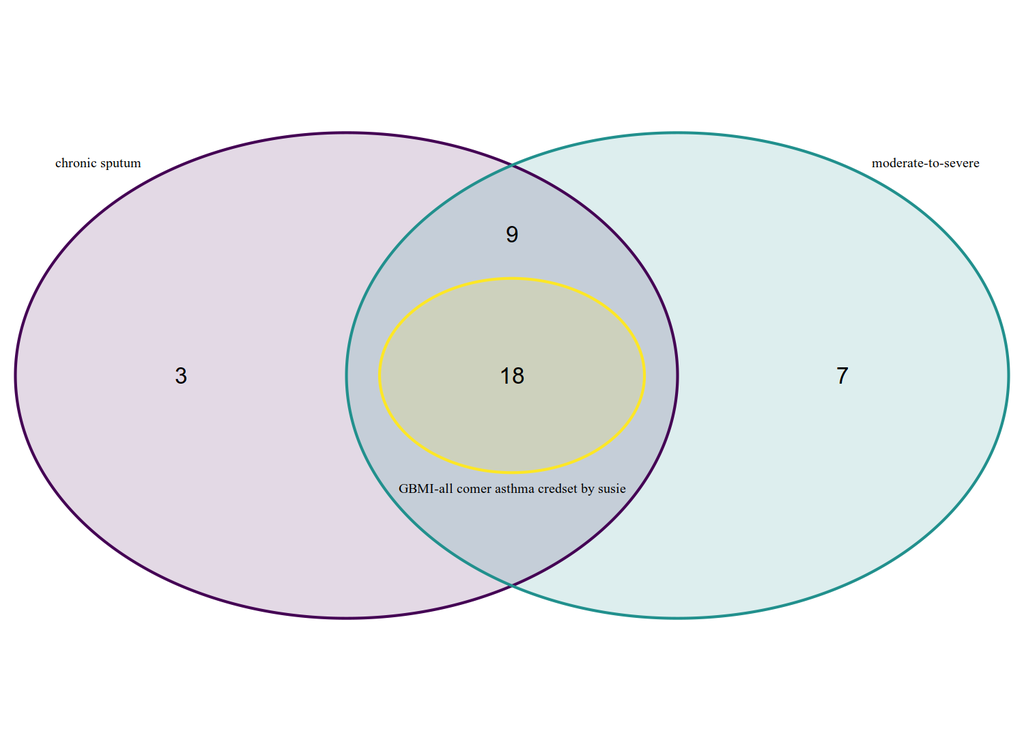

Figure 1. Venn diagram of the three 95% credible sets.

## SuSiE-only

For moderate-to-severe, the same variants were included in the 95% credible set, except for one. (Table 2, Figure 2) For GBMI, the non-functionally informed fine-mapping gave retrieved the same variants as for the Polyfun+SuSiE analysis.

[output not shown]

[output cut: 26 more lines]

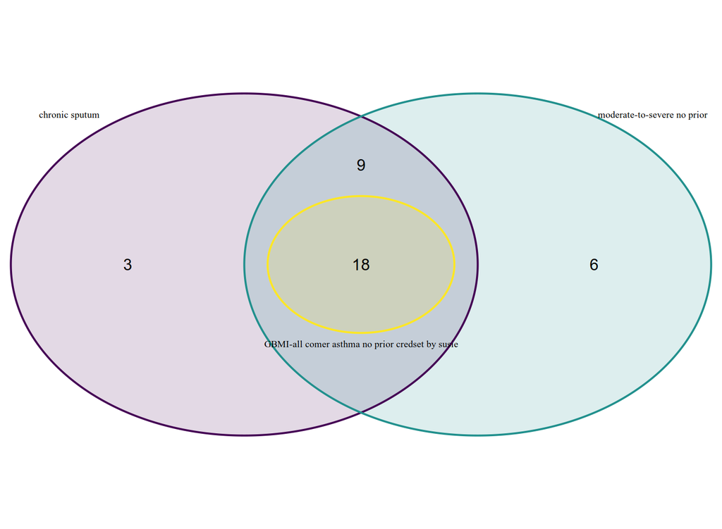

Figure 2. Venn diagram of the three 95% credible sets without functional priors.

# Conclusion

I retrieved mostly the same results with and without functionally-informed fine-mapping with 73% of overlap between at least two credible sets.  
To note: I used the pre-computed prior SNP probabilities calculated by polyfun’s authors. In doing so, I lost 441 and 389 variants in the fine-mapping for moderate-to-severe and GBMI study respectively, among which two variants that were found in the chronic sputum credible set (10.67% and 9.33% missing variants).  
To notice as well, polyfun’s author pointed out that results from meta-analysis may not be reliable (Table 3 in the main paper [1]) (https://github.com/omerwe/polyfun/issues/161).  
Finally, the sentinel variants for the chronic sputum study (rs779167905, merged into rs35606069; build 37: 1116931) is present in the summary statistics of the other two studies, but it was not found in the fine-mapping results.

# Notes: quality check ananlyses

In addition, I tried to use different parameters for minimum info score and maximum number of causal variants: info score 0.90, and 1 causal variant.  
For moderate-to-severe, all the variants were shared except for two (Figure 2):

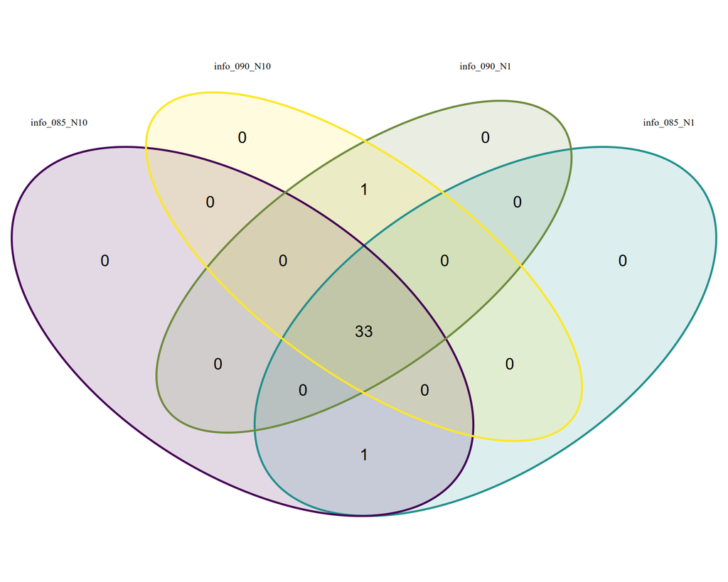

Figure 2. Venn diagram of the credible sets for different parameters for moderate-to-severe.

For GBMI all-comer asthma, having a different type of maximum causal variants influenced which variants are in the credible sets (Figure 3 and 4):

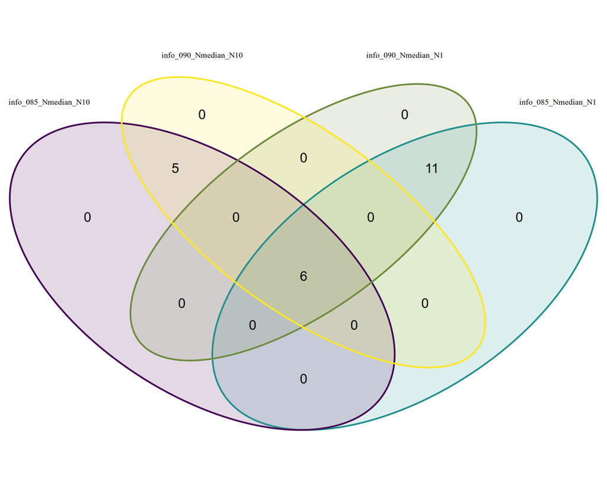

Figure 3. Venn diagram of the credible sets for different parameters for GBMI, with N = median sample size.

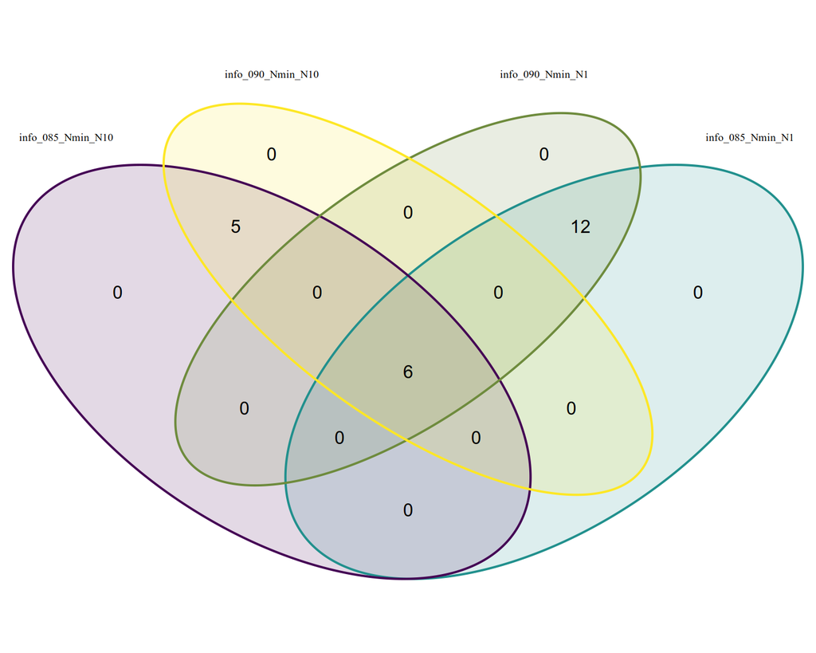

Figure 4. Venn diagram of the credible sets for different parameters for GBMI, with N = minimum sample size.

In the fine-mapping output, the column ‘CREDIBLE_SET’ sets in which possible credible set the variant is based on posterior inclusion probability the correlation between variants.  
For the moderate-to-severe study, SuSiE did not found any credible sets, so I used the cumulative sum approach: I took the variants with highest PIP until their sum reached 0.95%.  
For GBMI study, SuSiE identified one credible set with 18 variants, six of which were found in the previous credset for this study.

```bash
awk -F "," '{print $3}' output/polyfun_susie_gbmi_eur_Nmedian_credsetbysusie | grep -F -f - output/polyfun_susie_gbmi_eur_credset_Nmedian
```

Here, the Venn diagram updated with the GBMI credible set as by SuSiE (Figure 5). In this case, all the variants in the GBMI’s credible set were shared with the other two credible sets:

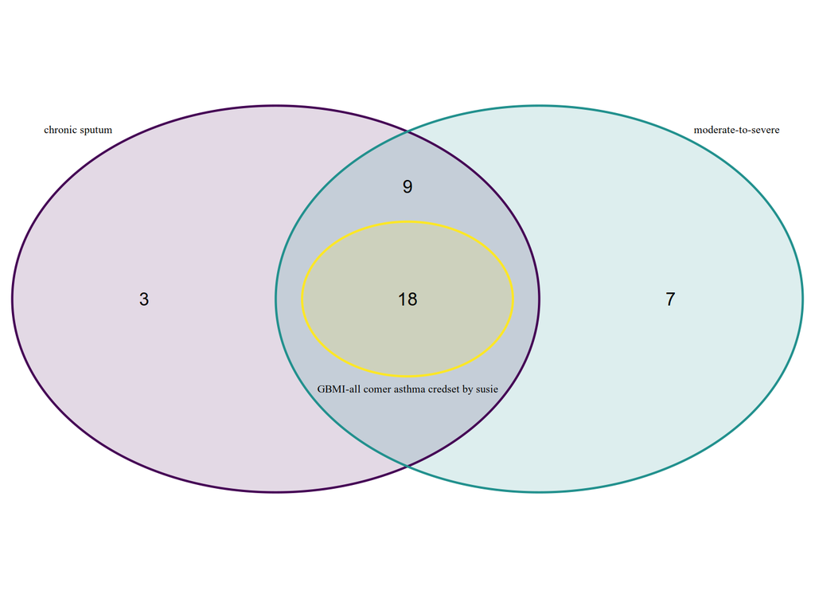

Figure 5. Venn diagram of the credible sets for different cohorts, with GBMI as found by SuSiE.

I also checked the GBMI fine-mapping with SuSiE not functionally-informed (Figure 6 and Figuere 7). In GBMI, the number of variants in the credible set changed according to the method used to define the credible set (‘CREDIBLE SET’ column equal to 1 / cumulative PIP <= 0.95).

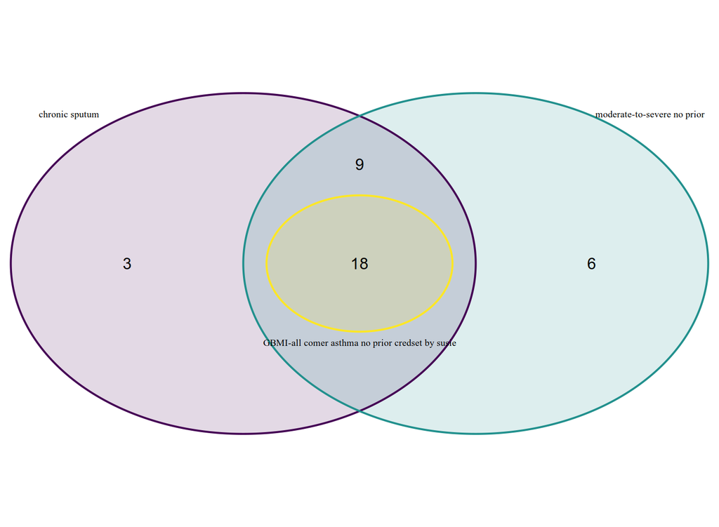

Figure 6. Venn diagram of the credible sets for different cohorts using SuSiE no-functional information, GBMI credible set as found by SuSiE.

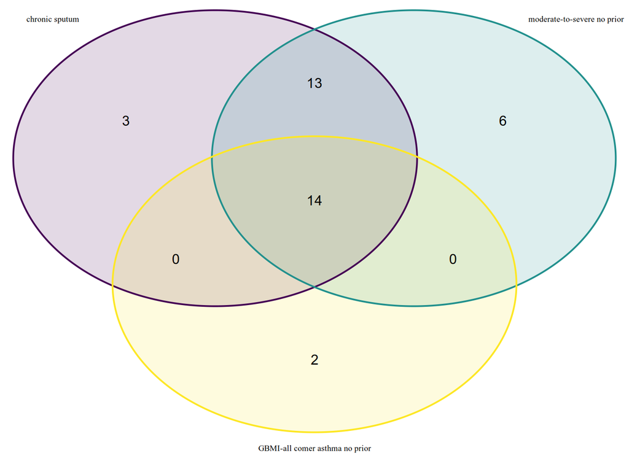

Figure 7. Venn diagram of the credible sets for different cohorts using SuSiE no-functional information, GBMI credible set as cumulative PIP < 0.95.

# References

1.Weissbrod 0. et al., Functionally informed fine-mapping and polygenic localization of complex trait heritability. Nat Genet 2020,doi:https://doi.org/10.1038/s41588-020-00735-5  
2.Zou Y. et al., Fine-mapping from summary data with the “Sum of Single Effects” model, Plos genetics 2022, doi:https://doi.org/10.1371/journal.pgen.1010299  
3.Shrine N et al., Moderate-to-severe asthma in individuals of European ancestry: a genome-wide association study. Lancet Respir Med. 2019, doi: 10.1016/S2213-2600(18)30389-8.  
4.Tsuo K. et al., Multi-ancestry meta-analysis of asthma identifies novel associations and highlights the value of increased power and diversity, Cell Genomics 2022, doi:https://doi.org/10.1016/j.xgen.2022.100212.  
5.Packer RJ et al., Genome-wide association study of chronic sputum production implicates loci involved in mucus production and infection. Eur Respir J. 2023, doi:10.1183/13993003.01667-2022. PMID: 37263751. https://github.com/omerwe/polyfun